# Application 5

Author

Martin Hsu

# Costco Time Markov Chains

**Cars arrive at the Costco gas station at rate $\lambda=1$ car per minute.**

## Part 1

**Let $X_i(t)$ denote the number of customers in queue $i=1,...,6$ at time $t$, including any customers in service at the corresponding pumps. The process $X(t)=(X_1(t),...,X_6(t))$ is a vector-valued continuous time Markov chain. Let $S(t)=X_1(t)+\cdots+X_6(t)$ denote the total number of customers in the system at time $t$, including any customers in service.**

**Write a program to simulate the customer arrivals and services and the values of $X_i(t)$ over a long time period, say a week. You will use your simulation results to approximate the following items, so consider all parts below when designing your code.**

- **The long run distribution of the** *number of cars in the system (waiting or in service).*
- **The long run fraction of time there are no cars in the system.**
- **The long run average number of customers in the system.**
- **Any other features of the long run distribution of the number of cars in the system you’re interested in**
- **The long run distribution of the** *amount of time a customer spends in the system (waiting time + service time). (This will require more work than just finding the number of customers in the system. You will need to track individual customers from the time they enter until the time they leave.)*
- **The average time a customer spends in the system.**
- **Any other features of the long run distribution of the amount of time a customer spends in the system you’re interested in**

### Setup

```r
library(tidyverse)
```

```r
set.seed(545)
```

### Level 1

Let’s begin with a simple system with one pump, one line and one type of customer. We will slowly modify this simulation to fulfill all the requirements of the Costco Gasoline queue.

```r
# Set arrival rate
lambda <- 1
# Set departure rate
mu <- 0.2
# Set time frame - 1 week in minutes
duration <- 60 * 24 * 7
# Initialize time tracker
t <- 0
# Xi = # of customers in system
# This is the underlying DTMC
Xi <- numeric()
# W = waiting times of customers
W <- numeric()
# times = time between states in DTMC
times <- numeric()
# initialize waiting times of people in queue
q_times <- numeric()
# Initialize start state - 0 customers
Xi[[1]] <- 0
# initialize event counter
i <- 1

# Begin simulation
while (t <= duration) {
  # Increment the underlying DTMC Xi to the next step
  # A new event as happened!
  i <- i + 1
  # Get number of people in line just prior to event happening
  ncurr <- Xi[[i-1]]

  # If there were no people in line before the event...
  if (ncurr == 0) {
    # Get time to event since last event using lambda only
    #   since event must be car arriving, not leaving
    wait <- rexp(1, lambda)
    # Add wait time until next state to times vector
    times <- c(times, wait)
    # Add wait time to overall time
    t <- t + wait
    # There is now one person in the queue who is being serviced!
    q_times <- 0
    Xi[[i]] <- 1
  # Otherwise, if there are >0 people in queue prior to event happening...
  } else {
    # Get wait time. It can either be person leaving or
    wait <- rexp(1, mu + lambda)
    # Add wait time until next state to times vector
    times <- c(times, wait)
    # Add wait time to overall time
    t <- t + wait
    # Add wait time to everyone who is currently in queue
    q_times <- q_times + wait
    # Generate next state of DTMC Xi
    # Either -1 wp mu/(mu+lambda) or 1 wp lambda/(mu+lambda)
    # This is based off the exponential race property
    increment <- sample(c(-1, 1), 1, prob = c(mu, lambda))
    Xi[[i]] <- ncurr + increment
    # If someone is leaving...
    if (increment == -1) {
      # That means we now have a complete wait time
      # Pop the first time off the queue and add it to the list of waiting times
      #   W
      W <- c(W, q_times[[1]])
      if (length(q_times) == 1) {
        q_times <- numeric()
      } else {
        q_times <- q_times[2:length(q_times)]
      }
    # If a car is arriving...
    } else if (increment == 1) {
      # Add a new person's waiting time to the queue
      q_times <- c(q_times, 0)
    }
  }
}
times <- c(times, 0)
```

Let’s view the CTMC:

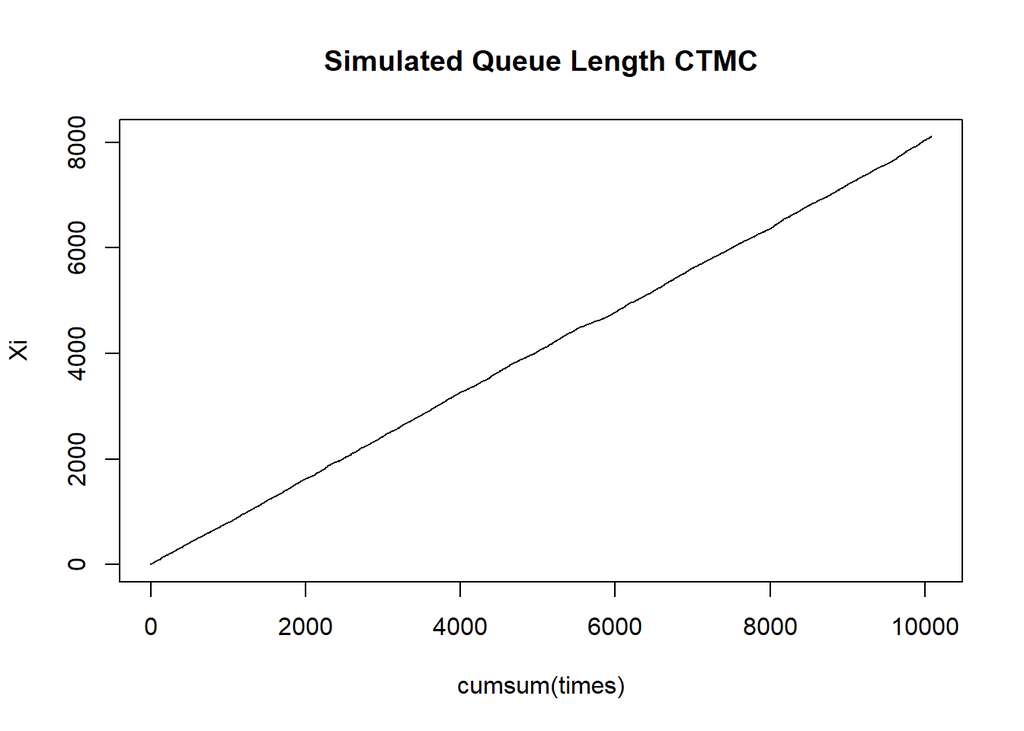

```r
plot(cumsum(times), Xi, type = "s", main = "Simulated Queue Length CTMC")
```

Let’s examine the underlying DTMC `Xi` of people in the queue, as well as the wait times of each person who passed through the queue `W`.

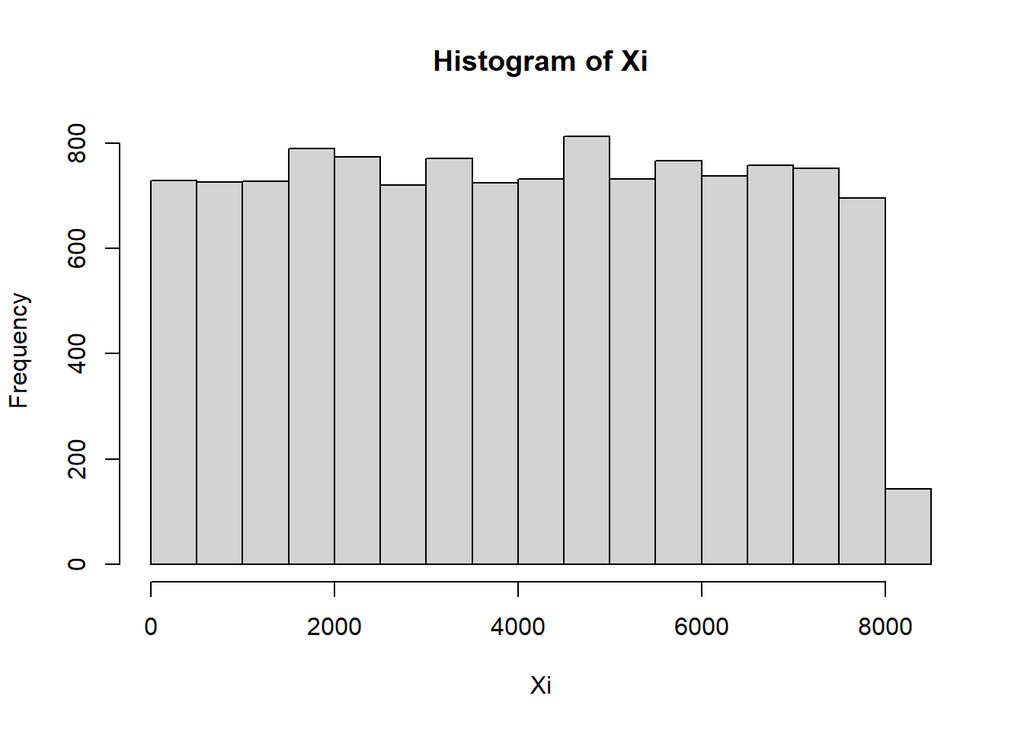

```r
hist(Xi)
```

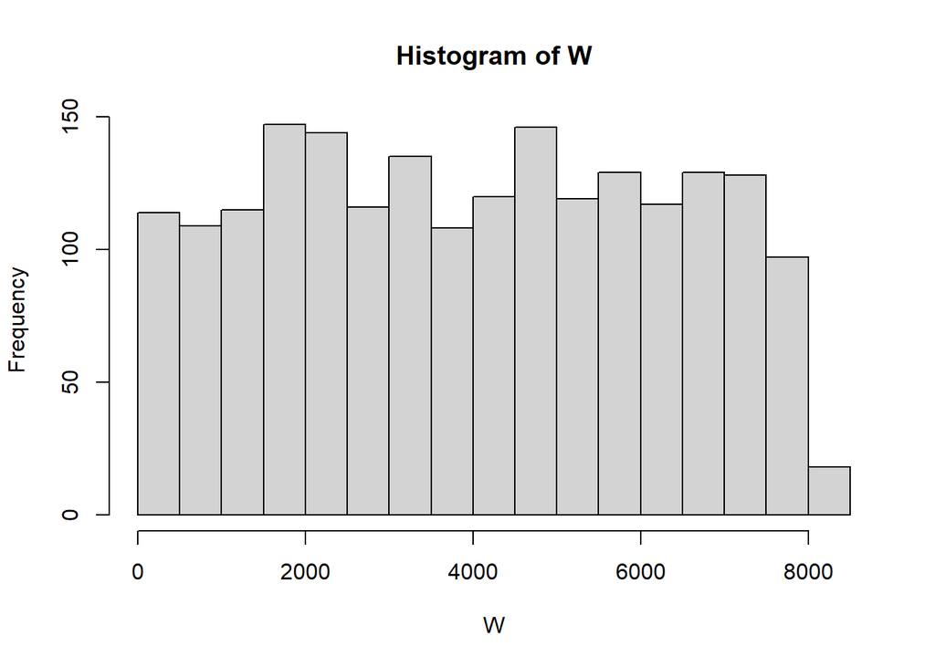

```r
hist(W)
```

```r
c("Xi" = mean(Xi), "W" = mean(W))
```

```
      Xi        W
4045.178 4016.291
```

### Level 2

Now on to the next level. Let’s simulate two pumps on the same side. What changes here? The leaving rate, instead of simply being mu, is now $\min(X_i(t), 2)\cdot\mu$ Either there is 1 person in the queue, which means that they leave at a rate $\mu$, or there are 2 or more people in the queue, in which case they leave at a rate $2\mu$. Modifying the simulation:

```r
lambda <- 1; mu <- 0.2
duration <- 60 * 24 * 7
t <- 0
Xi <- numeric(); W <- numeric()
times <- numeric()
q_times <- numeric()
Xi[[1]] <- 0
i <- 1

while (t <= duration) {
  i <- i + 1
  ncurr <- Xi[[i-1]]

  # New leaving rate, equal to 0 if there are no cars
  lrate <- min(ncurr, 2)*mu
  wait <- rexp(1, lrate + lambda)
  times <- c(times, wait)
  t <- t + wait
  q_times <- q_times + wait
  # New increment proportions in exponential race
  increment <- sample(c(-1, 1), 1, prob = c(lrate, lambda))
  Xi[[i]] <- ncurr + increment

  if (increment == -1) {
    if (ncurr == 1) {
      W <- c(W, q_times[[1]])
      q_times <- numeric()
    } else {
      # We need to choose who leaves if there are 2 people at pumps
      # It's a 50/50 chance by the exponential race
      # We also need to maintain ordering
      leaves <- sample(c(1, 2), 1)
      if (leaves == 1) {
        W <- c(W, q_times[[1]])
        if (ncurr == 2) {
          q_times <- q_times[[2]]
        } else if (ncurr == 3) {
          q_times <- q_times[c(3,2)]
        } else {
          q_times <- c(q_times[c(3,2)], q_times[4:length(q_times)])
        }
      } else if (leaves == 2) {
        W <- c(W, q_times[[2]])
        if (ncurr == 2) {
          q_times <- q_times[[1]]
        } else if (ncurr == 3) {
          q_times <- q_times[c(1,3)]
        } else {
          q_times <- c(q_times[c(1,3)], q_times[4:length(q_times)])
        }
      }
    }
  } else if (increment == 1) {
    q_times <- c(q_times, 0)
  }
}
times <- c(times, 0)
```

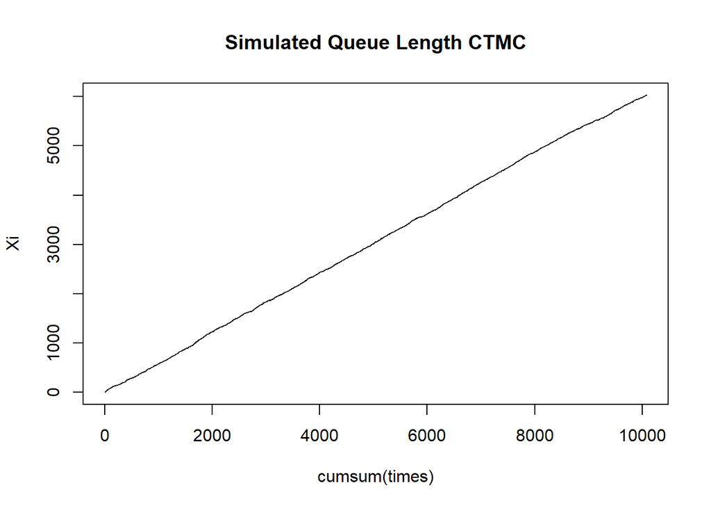

```r
plot(cumsum(times), Xi, type="s", main="Simulated Queue Length CTMC")
```

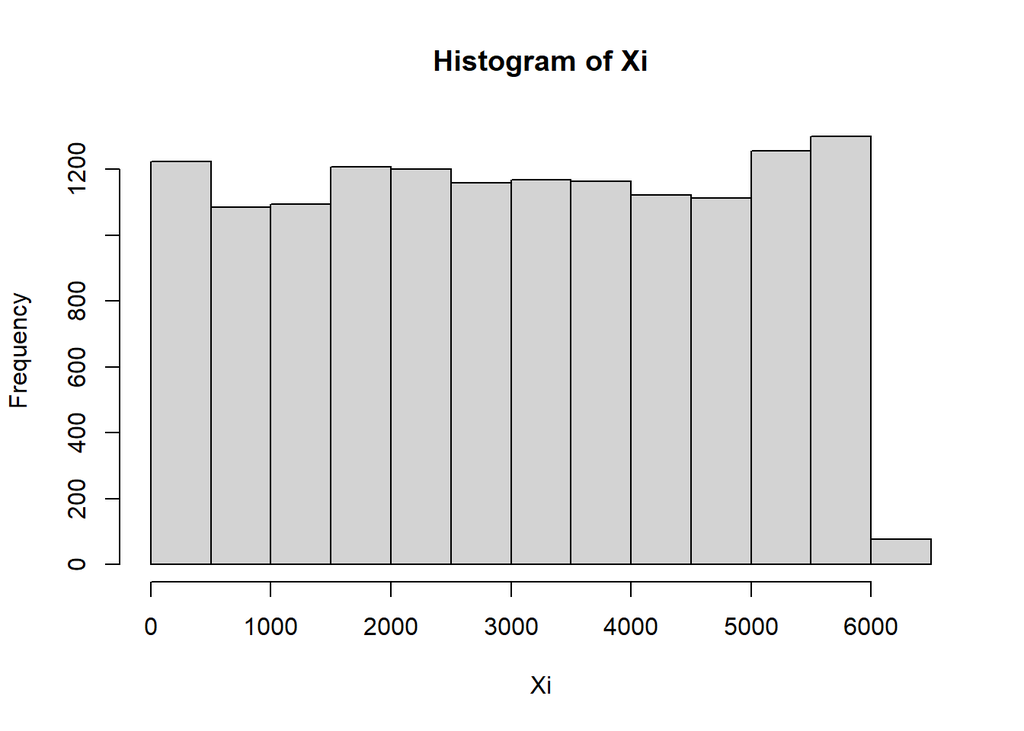

```r
hist(Xi)
```

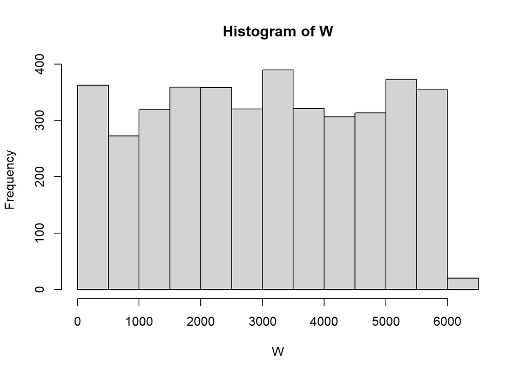

```r
hist(W)
```

```r
c("Xi" = mean(Xi), "W" = mean(W))
```

```
      Xi        W
3054.457 3053.445
```

### Level 3

Now, let’s simulate two pumps on either side. We will now have two queues. The leaving rate is now $\min(X_1(t),2)+\min(X_2(t),2)$. Modifying the simulation:

```r
lambda <- 1; mu <- 0.2
duration <- 60 * 24 * 7
t <- 0
# S is the total in queue across all Xi queues
# X is a matrix where each column is a different queue
# Beacuse there are 2 queues, X now has 2 columns instead of "1" column like
#   before
S <- numeric(); X <- t(matrix(c(0, 0))); W <- numeric()
times <- numeric()
# Times of people in queue are now also 2-column
q_times <- list(numeric(), numeric())
S[[1]] <- 0
i <- 1

while (t <= duration) {
  i <- i + 1
  ncurr <- X[i-1,]
  # Set new states equal to old states, we will update the state of the queue
  #   that changes
  X <- rbind(X, ncurr)
  # New leaving rate. It will be equal to 0 if no one is at the queues
  lrate <- sum(sapply(ncurr, function(x) min(x, 2))) * mu

  # New wait time
  wait <- rexp(1, rate = lrate + lambda)
  times <- c(times, wait)
  t <- t + wait
  q_times <- lapply(q_times, function(x) x + wait)
  increment <- sample(c(-1, 1), 1, prob = c(lrate, lambda))

  if (increment == 1) {
    # If person arrives, they arrive at the shortest queue
    queue <- which(ncurr == min(ncurr))
    # If more than one shortest queue, choose a random one
    if (length(queue) > 1) {
      queue <- sample(queue, 1)
    }
    # Update state of the selected queue. All other states stay the same.
    X[[i,queue]] <- ncurr[queue] + 1

    q_times[[queue]] <- c(q_times[[queue]], 0)
  } else if (increment == -1) {
    # Choose which queue to leave
    # Probability of a queue being the one left is proportional to the number
    #   of cars at its pump
    queue <- sample(c(1,2), 1, prob = sapply(ncurr, function(x) min(x, 2)))
    # Update state of the selected queue. All other states stay the same.
    X[[i,queue]] <- ncurr[queue] - 1

    q_times_i <- q_times[[queue]]
    if (ncurr[queue] == 1) {
      W <- c(W, q_times_i[[1]])
      q_times[[queue]] <- numeric()
    } else {
      leaves <- sample(c(1, 2), 1)
      if (leaves == 1) {
        W <- c(W, q_times_i[[1]])
        if (ncurr[queue] == 2) {
          q_times_i <- q_times_i[[2]]
        } else if (ncurr[queue] == 3) {
          q_times_i <- q_times_i[c(3,2)]
        } else {
          q_times_i <- c(q_times_i[c(3,2)], q_times_i[4:length(q_times_i)])
        }
      } else if (leaves == 2) {
        W <- c(W, q_times_i[[2]])
        if (ncurr[queue] == 2) {
          q_times_i <- q_times_i[[1]]
        } else if (ncurr[queue] == 3) {
          q_times_i <- q_times_i[c(1,3)]
        } else {
          q_times_i <- c(q_times_i[c(1,3)], q_times_i[4:length(q_times_i)])
        }
      }
      q_times[[queue]] <- q_times_i
    }
  }
  S[[i]] <- sum(X[i,])
}
times <- c(times, 0)
rownames(X) <- NULL
```

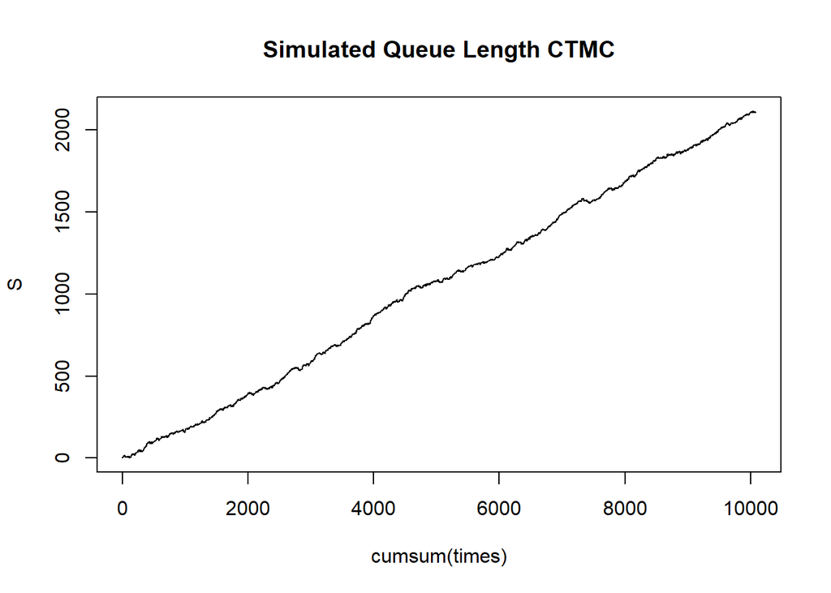

```r
plot(cumsum(times), S, type="s", main="Simulated Queue Length CTMC")
```

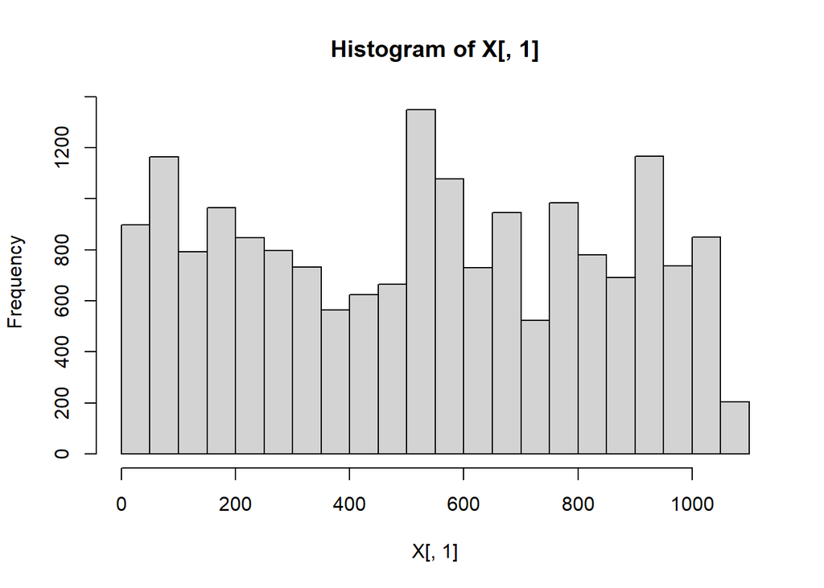

```r
hist(X[,1])
```

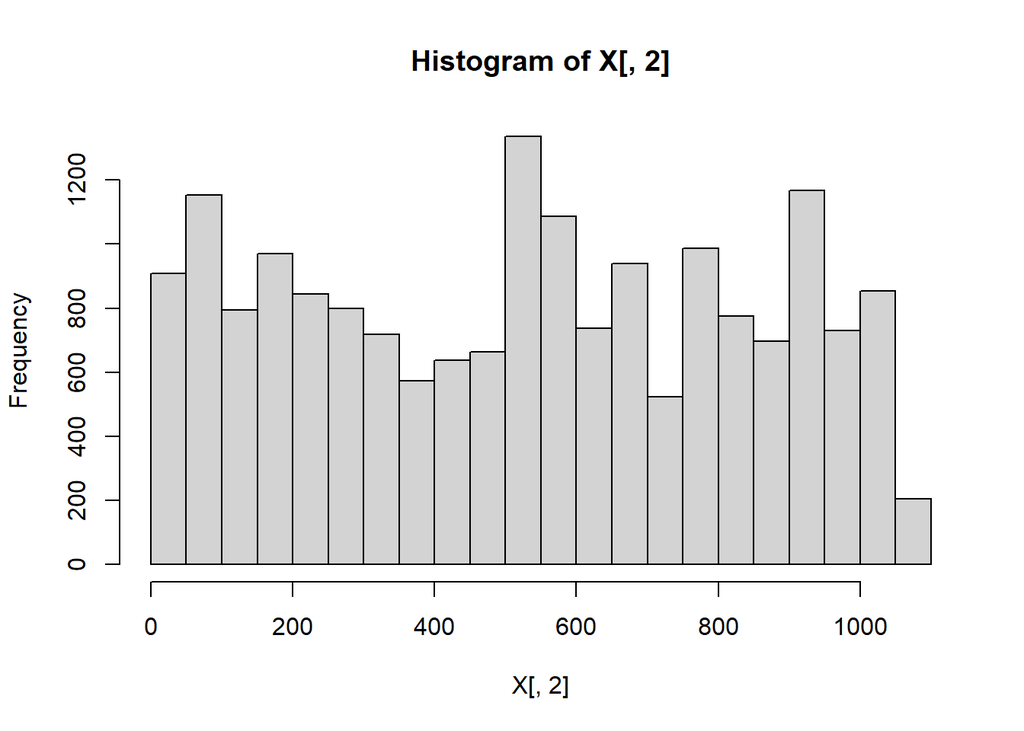

```r
hist(X[,2])
```

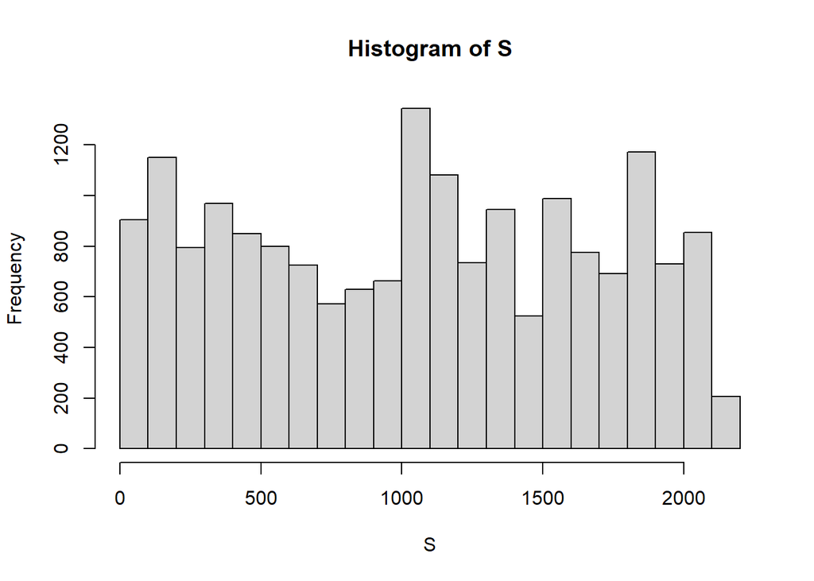

```r
hist(S)
```

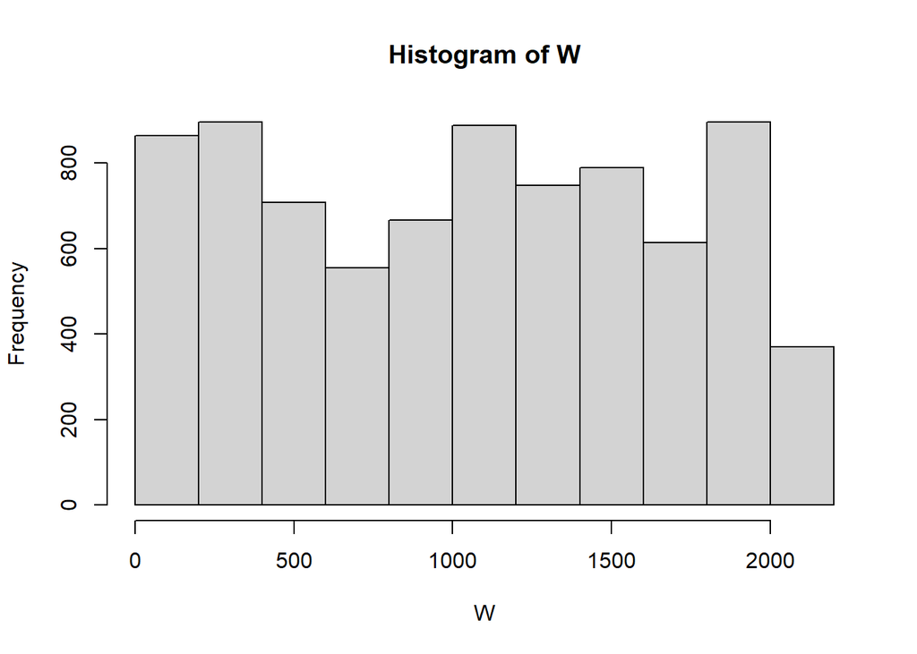

```r
hist(W)
```

```r
c("S" = mean(S), "X1" = mean(X[,1]), "X2" = mean(X[,2]), "W" = mean(W))
```

```
        S        X1        X2         W
1053.8912  526.9622  526.9290 1048.7173
```

### Level 4

We know that cars have left/right/either preference, so let’s incorporate that here. Modifying the simulation:

```r
lambda <- 1; mu <- 0.2
duration <- 60 * 24 * 7
t <- 0
S <- numeric(); X <- t(matrix(c(0, 0))); W <- numeric()
times <- numeric()
q_times <- list(numeric(), numeric())
S[[1]] <- 0
i <- 1

while (t <= duration) {
  i <- i + 1
  ncurr <- X[i-1,]
  X <- rbind(X, ncurr)
  lrate <- sum(sapply(ncurr, function(x) min(x, 2))) * mu

  wait <- rexp(1, rate = lrate + lambda)
  times <- c(times, wait)
  t <- t + wait
  q_times <- lapply(q_times, function(x) x + wait)
  increment <- sample(c(-1, 1), 1, prob = c(lrate, lambda))

  if (increment == 1) {
    # Generate car preference based on distribution
    pref <- sample(c("Odd", "Even", "Both"), 1, prob = c(0.3, 0.3, 0.4))
    # If car preference is odd/left side pump...
    if (pref == "Odd") {
      # Get the minimum of the odd indices
      pref_min <- min(ncurr[seq(1, length(ncurr), by = 2)])
      # Find the queue with the odd argmin
      queue <- which((ncurr == pref_min) & ((1:length(ncurr) + 1) %% 2 == 0))
    # If car preference is even/right side pump...
    } else if (pref == "Even") {
      # Get the minimum of the even indices
      pref_min <- min(ncurr[seq(2, length(ncurr), by = 2)])
      # Find the queue with the even argmin
      queue <- which((ncurr == pref_min) & ((1:length(ncurr)) %% 2 == 0))
    # If no car preference...
    } else if (pref == "Both") {
      # Find queue with overall argmin
      queue <- which(ncurr == min(ncurr))
    }
    # If more than 1 min, randomly choose 1
    if (length(queue) > 1) {
      queue <- sample(queue, 1)
    }
    X[[i,queue]] <- ncurr[queue] + 1

    q_times[[queue]] <- c(q_times[[queue]], 0)
  } else if (increment == -1) {
    queue <- sample(c(1,2), 1, prob = sapply(ncurr, function(x) min(x, 2)))
    X[[i,queue]] <- ncurr[queue] - 1

    q_times_i <- q_times[[queue]]
    if (ncurr[queue] == 1) {
      W <- c(W, q_times_i[[1]])
      q_times[[queue]] <- numeric()
    } else {
      leaves <- sample(c(1, 2), 1)
      if (leaves == 1) {
        W <- c(W, q_times_i[[1]])
        if (ncurr[queue] == 2) {
          q_times_i <- q_times_i[[2]]
        } else if (ncurr[queue] == 3) {
          q_times_i <- q_times_i[c(3,2)]
        } else {
          q_times_i <- c(q_times_i[c(3,2)], q_times_i[4:length(q_times_i)])
        }
      } else if (leaves == 2) {
        W <- c(W, q_times_i[[2]])
        if (ncurr[queue] == 2) {
          q_times_i <- q_times_i[[1]]
        } else if (ncurr[queue] == 3) {
          q_times_i <- q_times_i[c(1,3)]
        } else {
          q_times_i <- c(q_times_i[c(1,3)], q_times_i[4:length(q_times_i)])
        }
      }
      q_times[[queue]] <- q_times_i
    }
  }
  S[[i]] <- sum(X[i,])
}
times <- c(times, 0)
rownames(X) <- NULL
```

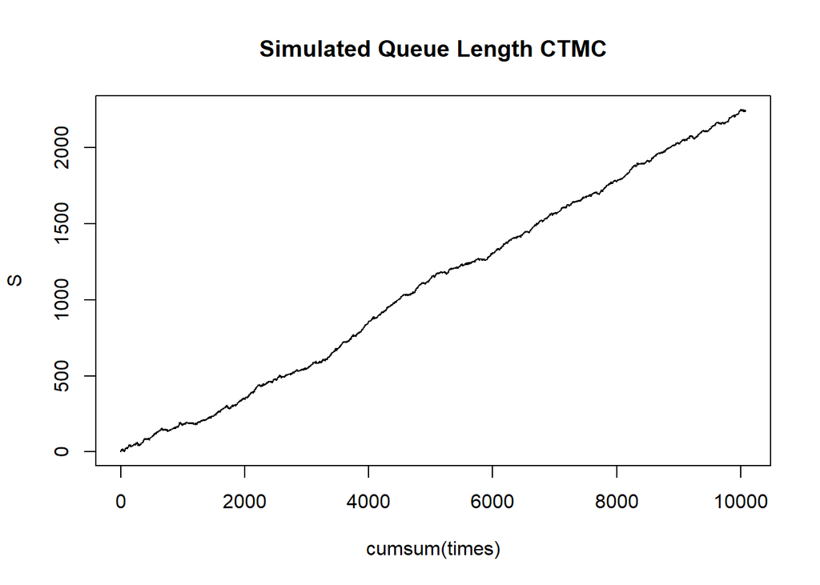

```r
plot(cumsum(times), S, type="s", main="Simulated Queue Length CTMC")
```

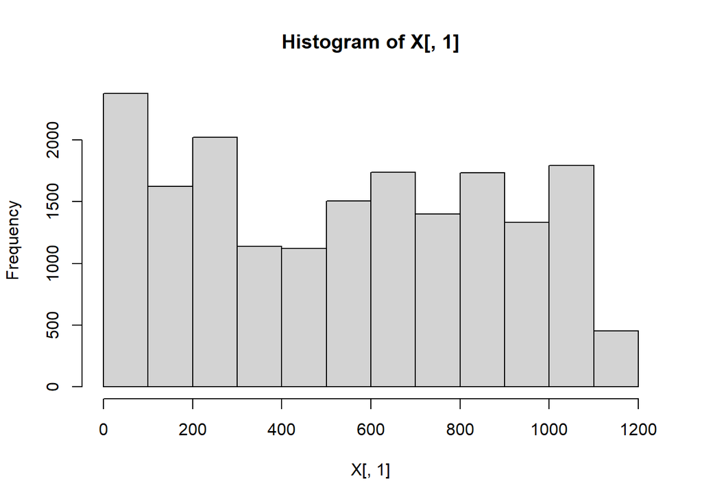

```r
hist(X[,1])
```

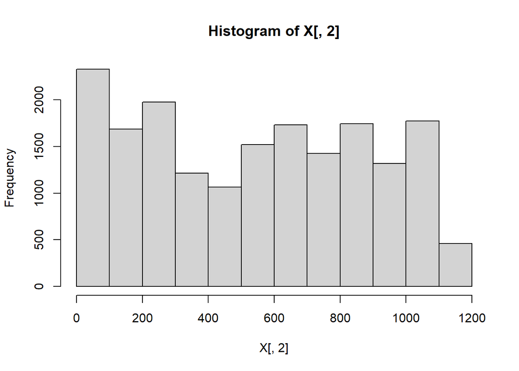

```r
hist(X[,2])
```

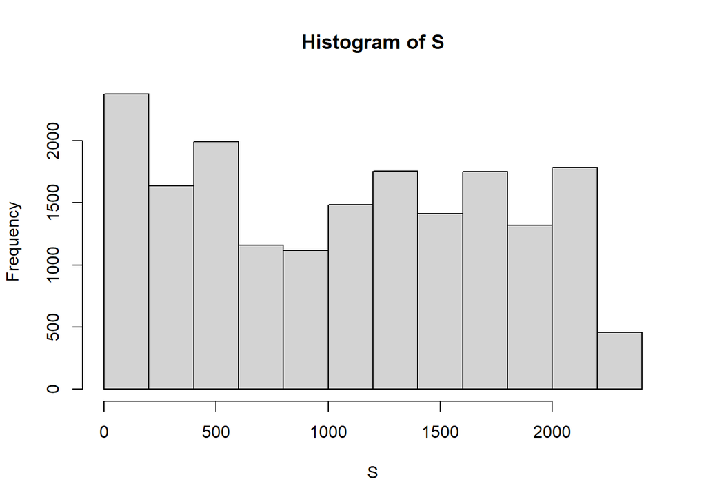

```r
hist(S)
```

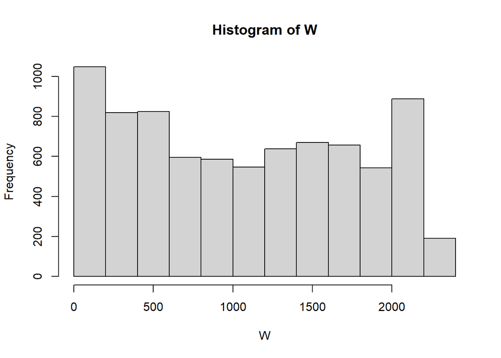

```r
hist(W)
```

```r
c("S" = mean(S), "X1" = mean(X[,1]), "X2" = mean(X[,2]), "W" = mean(W))
```

```
        S        X1        X2         W
1088.4427  544.0481  544.3945 1072.7515
```

### Final Simulation

Now, let’s increase the number of queues to 6 (or 3 islands). This will complete our simulation by satisfying all specified requirements. Modifying the simulation:

```r
lambda <- 1; mu <- 0.2
duration <- 60 * 24 * 7; t <- 0
# There are now 6 queues
q <- 6
S <- numeric(); X <- t(matrix(rep(0, q))); W <- numeric()
times <- numeric()
q_times <- rep(list(numeric()), times=q)
S[[1]] <- 0; i <- 1

while (t <= duration) {
  i <- i + 1
  ncurr <- X[i-1,]
  X <- rbind(X, ncurr)
  lrate <- sum(sapply(ncurr, function(x) min(x, 2))) * mu
  wait <- rexp(1, rate = lrate + lambda)
  times <- c(times, wait)
  t <- t + wait
  q_times <- lapply(q_times, function(x) x + wait)
  increment <- sample(c(-1, 1), 1, prob = c(lrate, lambda))

  if (increment == 1) {
    pref <- sample(c("Odd", "Even", "Both"), 1, prob = c(0.3, 0.3, 0.4))
    if (pref == "Odd") {
      pref_min <- min(ncurr[seq(1, length(ncurr), by = 2)])
      queue <- which((ncurr == pref_min) & ((1:length(ncurr) + 1) %% 2 == 0))
    } else if (pref == "Even") {
      pref_min <- min(ncurr[seq(2, length(ncurr), by = 2)])
      queue <- which((ncurr == pref_min) & ((1:length(ncurr)) %% 2 == 0))
    } else if (pref == "Both") {
      queue <- which(ncurr == min(ncurr))
    }

    if (length(queue) > 1) {
      queue <- sample(queue, 1)
    }
    X[[i,queue]] <- ncurr[queue] + 1

    q_times[[queue]] <- c(q_times[[queue]], 0)
  } else if (increment == -1) {
    queue <- sample(1:q, 1, prob = sapply(ncurr, function(x) min(x, 2)))
    X[[i,queue]] <- ncurr[queue] - 1

    q_times_i <- q_times[[queue]]
    if (ncurr[queue] == 1) {
      W <- c(W, q_times_i[[1]])
      q_times[[queue]] <- numeric()
    } else {
      leaves <- sample(c(1, 2), 1)
      if (leaves == 1) {
        W <- c(W, q_times_i[[1]])
        if (ncurr[queue] == 2) {
          q_times_i <- q_times_i[[2]]
        } else if (ncurr[queue] == 3) {
          q_times_i <- q_times_i[c(3,2)]
        } else {
          q_times_i <- c(q_times_i[c(3,2)], q_times_i[4:length(q_times_i)])
        }
      } else if (leaves == 2) {
        W <- c(W, q_times_i[[2]])
        if (ncurr[queue] == 2) {
          q_times_i <- q_times_i[[1]]
        } else if (ncurr[queue] == 3) {
          q_times_i <- q_times_i[c(1,3)]
        } else {
          q_times_i <- c(q_times_i[c(1,3)], q_times_i[4:length(q_times_i)])
        }
      }
      q_times[[queue]] <- q_times_i
    }
  }
  S[[i]] <- sum(X[i,])
}
times <- c(times, 0)
rownames(X) <- NULL
```

Below, we can plot the distribution for each $X_i$, or the distribution of the number of cars in each queue in the underlying DTMC.

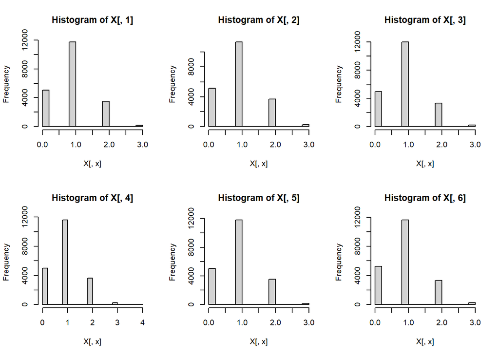

```r
par(mfrow = c(2, 3))
for (x in 1:6) {
  hist(X[,x], main = paste("Histogram of X[, ", x, "]", sep=""))
}
```

Here is the distribution of the total cars waiting in the queue in the underlying DTMC

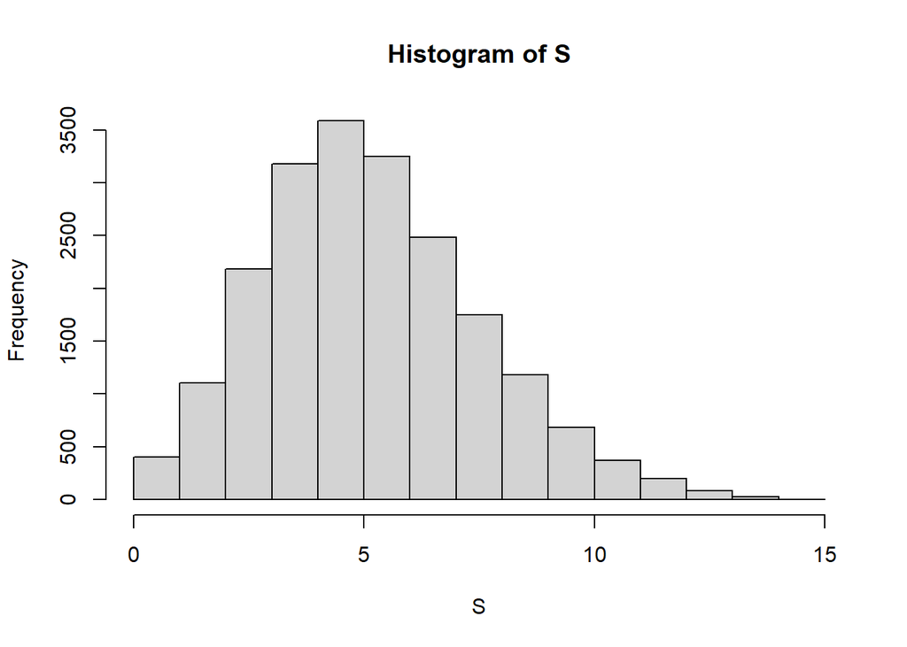

```r
hist(S)
```

Below is the distribution of car waiting times.

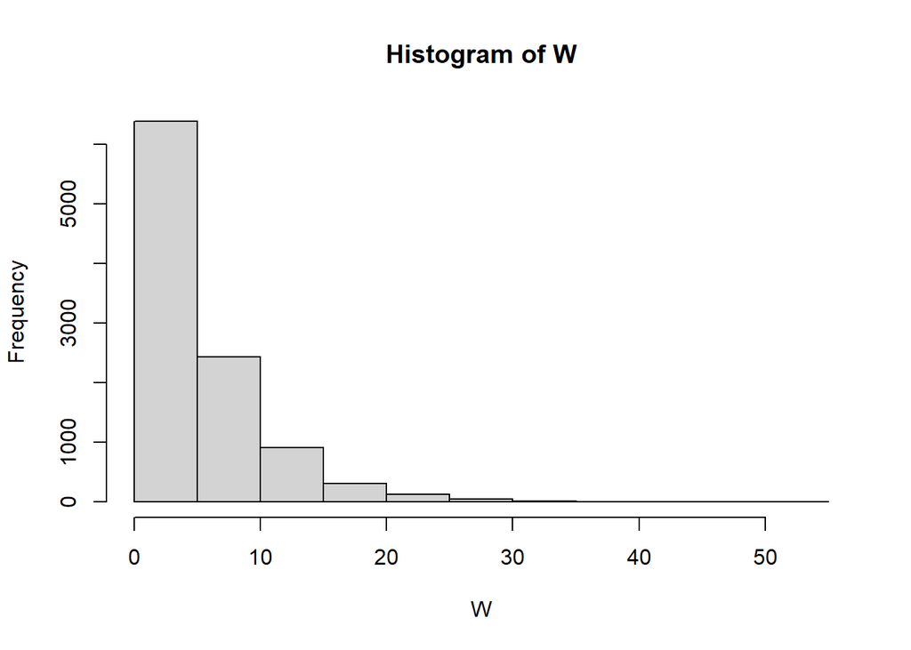

```r
hist(W)
```

Below are the mean values of each DTMC.

```r
c("S" = mean(S),
  "X1" = mean(X[,1]), "X2" = mean(X[,2]), "X3" = mean(X[,3]),
  "X4" = mean(X[,1]), "X5" = mean(X[,2]), "X6" = mean(X[,3]),
  "W" = mean(W))
```

```
        S        X1        X2        X3        X4        X5        X6         W
5.6662761 0.9388303 0.9564538 0.9402949 0.9388303 0.9564538 0.9402949 5.0678299
```

Below is the CTMC from our Costco queueing simulation.

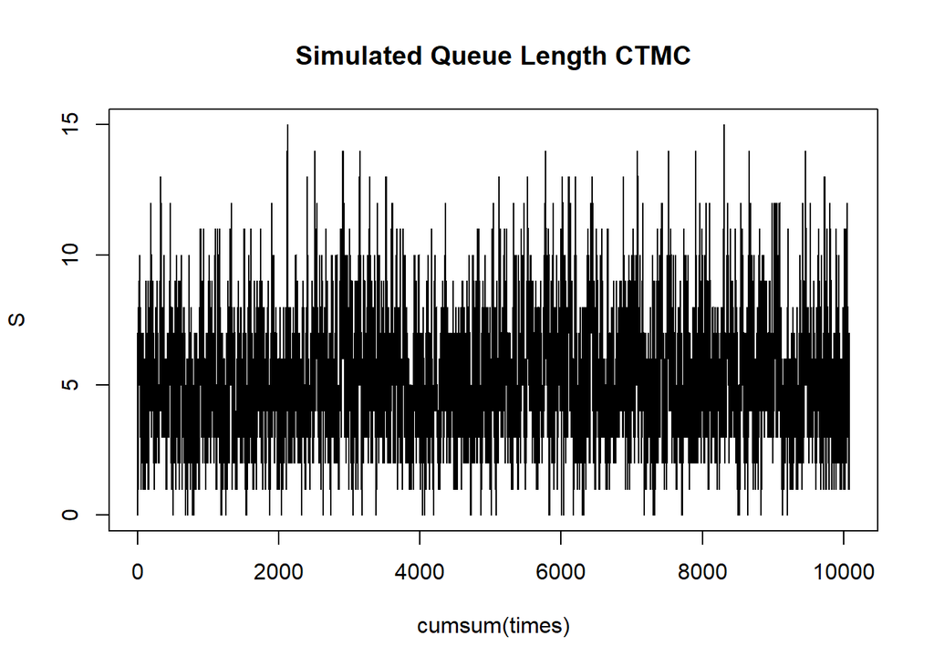

```r
plot(cumsum(times), S, type = "s", main = "Simulated Queue Length CTMC")
```

Here is the distribution of the total cars waiting in the queue in the CTMC.

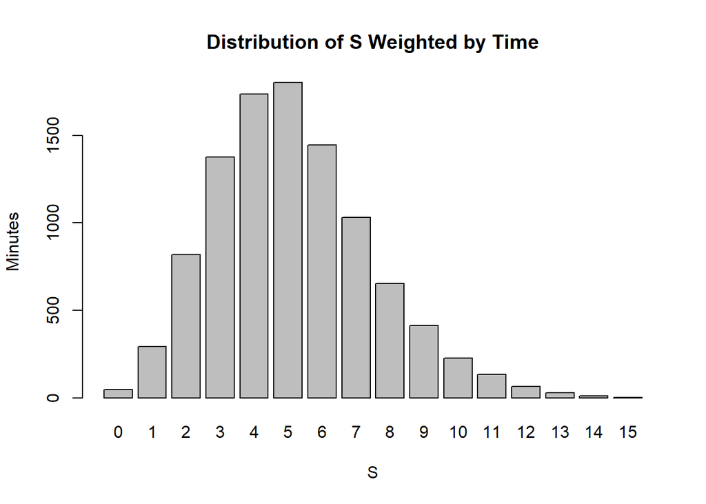

```r
time_dist <- cbind(S, times) %>%
  as.data.frame() %>%
  group_by(S) %>%
  summarize(time = sum(times))

barplot(time_dist$time, names.arg = time_dist$S,
        main = "Distribution of S Weighted by Time",
        xlab = "S", ylab = "Minutes")
```

Below are the proportions of time spent in each state, including when there are 0 cars.

```r
props <- time_dist %>%
  mutate(time = time / sum(time))
props
```

| S | time |
| --- | --- |
| 0 | 4.544203e-03 |
| 1 | 2.918107e-02 |
| 2 | 8.125514e-02 |
| 3 | 1.364430e-01 |
| 4 | 1.720987e-01 |
| 5 | 1.787495e-01 |
| 6 | 1.434437e-01 |
| 7 | 1.021936e-01 |
| 8 | 6.485614e-02 |
| 9 | 4.096077e-02 |

[output cut: 6 more lines]

```r
S_mean <- props %>%
  mutate(weight = S * time) %>%
  pull(weight) %>%
  sum()

S_moment2 <- props %>%
  mutate(weight = S^2 * time) %>%
  pull(weight) %>%
  sum()

S_sd <- sqrt(S_moment2 - S_mean^2)

c("S_mean" = S_mean, "S_sd" = S_sd)
```

```
  S_mean     S_sd
5.148999 2.331422
```

### Simulation Analysis

- The long-run distribution of cars in the system is approximated in the plot below. The distribution is discrete and right skew but looks approximately normal.

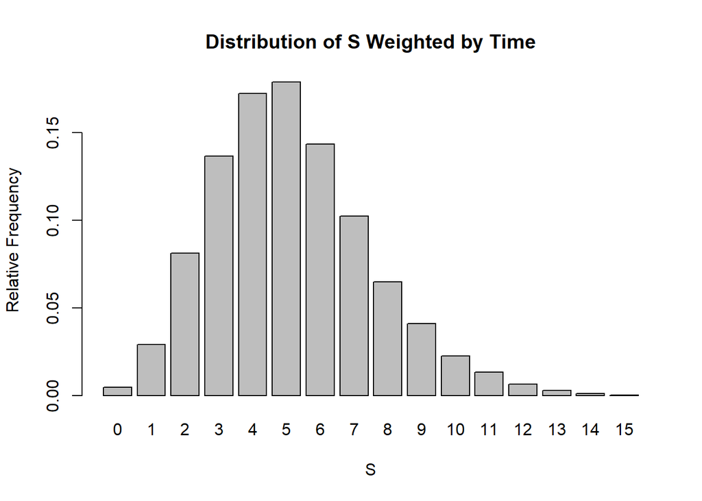

```r
barplot(props$time, names.arg = props$S,
        main = "Distribution of S Weighted by Time",
        xlab = "S", ylab = "Relative Frequency")
```

- The simulation spent about 0.454% of its time with no cars in the system.
- The estimated long run average number of customers in the system, weighted by time, was 5.149.
- The long run distribution of customer waiting times is approximated in the plot below. The distribution looks approximately exponential.

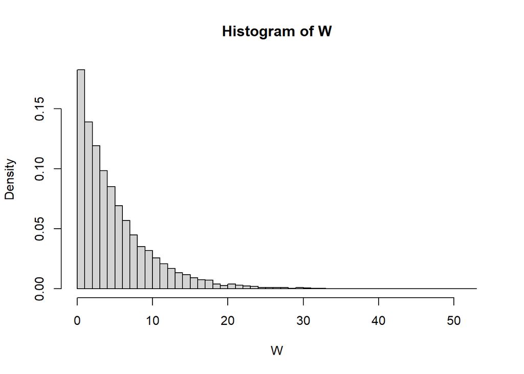

```r
hist(W, breaks=50, probability = T)
```

- The estimated average time a customer spends in the system is 5.068 minutes.

## Part 2

**Change some features of the set up and investigate how your changes effect the average number of customers in the system, and the average time a customer spends in the system.**

Let’s investigate how changing the “dimensions” of the gas pump layout affects the waiting time and number of customers in the system. In this particular example, since we have 12 pumps, how would the mean waiting time and mean number of customers in the system compare for the following layouts:

- 1 queue, 12 pumps per queue
- 2 queues, 6 pumps per queue
- 3 queues, 4 pumps per queue
- 4 queues, 3 pumps per queue
- 6 queues, 2 pumps per queue
- 12 queues, 1 pump per queue

All rules outlined in the problem will apply.

First, let’s generalize our simulation as a function that takes in parameters for the number of queues and the number of pumps at each queue:

```r
costco_sim <- function(q, npumps, sidepref = TRUE) {
  lambda <- 1; mu <- 0.2
  duration <- 60 * 24 * 7; t <- 0
  S <- numeric(); X <- t(matrix(rep(0, q))); W <- numeric()
  times <- numeric()
  q_times <- rep(list(numeric()), times=q)
  S[[1]] <- 0; i <- 1

  while (t <= duration) {
    i <- i + 1
    ncurr <- X[i-1,]
    X <- rbind(X, ncurr)
    lrate <- sum(sapply(ncurr, function(x) min(x, npumps))) * mu
    wait <- rexp(1, rate = lrate + lambda)
    times <- c(times, wait)
    t <- t + wait
    q_times <- lapply(q_times, function(x) x + wait)
    increment <- sample(c(-1, 1), 1, prob = c(lrate, lambda))

    if (increment == 1) {
      # Edit vehicle preference to handle one queue
      if ((q == 1) | !(sidepref)) {
        queue <- which(ncurr == min(ncurr))
      } else {
        pref <- sample(c("Odd", "Even", "Both"), 1, prob = c(0.3, 0.3, 0.4))
        if (pref == "Odd") {
          pref_min <- min(ncurr[seq(1, length(ncurr), by = 2)])
          queue <- which((ncurr == pref_min) & ((1:length(ncurr) + 1) %% 2 == 0))
        } else if (pref == "Even") {
          pref_min <- min(ncurr[seq(2, length(ncurr), by = 2)])
          queue <- which((ncurr == pref_min) & ((1:length(ncurr)) %% 2 == 0))
        } else if (pref == "Both") {
          queue <- which(ncurr == min(ncurr))
        }
      }

      if (length(queue) > 1) {
        queue <- sample(queue, 1)
      }
      X[[i,queue]] <- ncurr[queue] + 1

      q_times[[queue]] <- c(q_times[[queue]], 0)
    } else if (increment == -1) {
      queue <- sample(1:q, 1, prob = sapply(ncurr, function(x) min(x, npumps)))
      X[[i,queue]] <- ncurr[queue] - 1

      q_times_i <- q_times[[queue]]
      if (ncurr[queue] == 1) {
        W <- c(W, q_times_i[[1]])
        q_times[[queue]] <- numeric()
      # Modify for general cases for different pump numbers
      } else if (ncurr[queue] <= npumps) {
        leaves <- sample(1:ncurr[queue], 1)
        stays <- c(1:ncurr[queue])[1:ncurr[queue] != leaves]
        W <- c(W, q_times_i[[leaves]])
        q_times[[queue]] = q_times[[queue]][stays]
      } else {
        leaves <- sample(1:npumps, 1)
        stays <- c(1:npumps)[1:npumps != leaves]
        W <- c(W, q_times_i[[leaves]])
        q_times[[queue]] <- c(q_times[[queue]][stays],
                              q_times[[queue]][(npumps+1):ncurr[queue]])
      }
    }
    S[[i]] <- sum(X[i,])
  }
  times <- c(times, 0)
  rownames(X) <- NULL

  S_mean <- cbind(S, times) %>%
    as.data.frame() %>%
    group_by(S) %>%
    summarize(time = sum(times)) %>%
    mutate(time = time / sum(time)) %>%
    mutate(weight = S * time) %>%
    pull(weight) %>%
    sum()

  return(c(S_mean, mean(W)))
}
```

### With Vehicle Side Preference

Now, let’s run on all queue/pump dimensions that result in a total of 12 pumps:

```r
dims <- list(c(1,12), c(2, 6), c(3, 4), c(4, 3), c(6, 2), c(12, 1))
results_all <- numeric()
for (dim in dims) {
  q <- dim[1]; npumps <- dim[2]
  results <- costco_sim(q, npumps, sidepref = TRUE)
  results_all <- rbind(results_all, results)
}
rownames(results_all) <- NULL
colnames(results_all) <- c("S_mean", "W_mean")
```

```r
results_table <- cbind(
  "nqueue" = c(1, 2, 3, 4, 6, 12),
  "npumps" = c(12, 6, 4, 3, 2, 1),
  results_all
) %>%
  as.data.frame()
results_table
```

| nqueue | npumps | S_mean | W_mean |
| --- | --- | --- | --- |
| 1 | 12 | 5.006903 | 5.051215 |
| 2 | 6 | 5.013160 | 4.939816 |
| 3 | 4 | 4.978733 | 4.984591 |
| 4 | 3 | 4.892439 | 4.957434 |
| 6 | 2 | 5.098366 | 5.106910 |
| 12 | 1 | 5.042429 | 5.037164 |

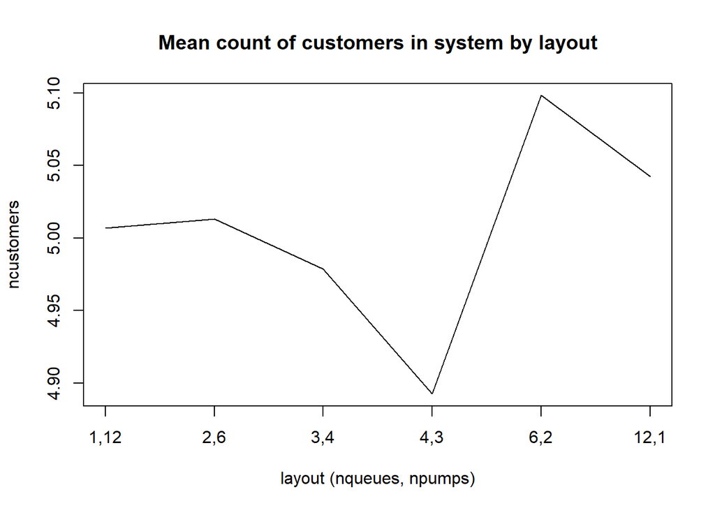

```r
plot(results_all[,"S_mean"], xaxt = "n", type="l",
     xlab="layout (nqueues, npumps)", ylab="ncustomers",
     main="Mean count of customers in system by layout")
axis(side = 1, at = seq(1, 6, by = 1),
     labels = c("1,12", "2,6", "3,4", "4,3", "6,2", "12,1"))
```

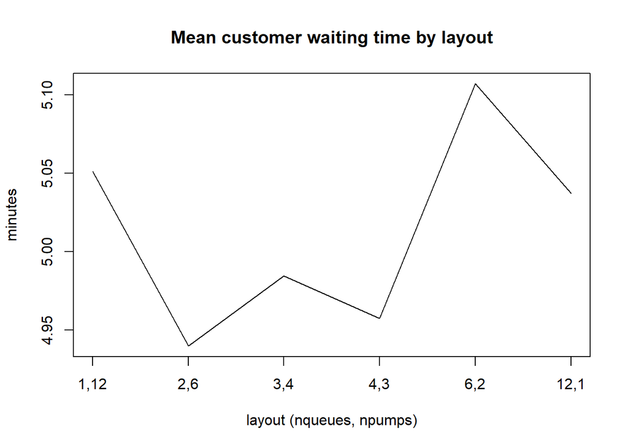

```r
plot(results_all[,"W_mean"], xaxt = "n", type="l",
     xlab="layout (nqueues, npumps)", ylab="minutes",
     main="Mean customer waiting time by layout")
axis(side = 1, at = seq(1, 6, by = 1),
     labels = c("1,12", "2,6", "3,4", "4,3", "6,2", "12,1"))
```

### Without Vehicle Side Preference

```r
dims <- list(c(1,12), c(2, 6), c(3, 4), c(4, 3), c(6, 2), c(12, 1))
results_all <- numeric()
for (dim in dims) {
  q <- dim[1]; npumps <- dim[2]
  results <- costco_sim(q, npumps, sidepref = FALSE)
  results_all <- rbind(results_all, results)
}
rownames(results_all) <- NULL
colnames(results_all) <- c("S_mean", "W_mean")
```

```r
results_table <- cbind(
  "nqueue" = c(1, 2, 3, 4, 6, 12),
  "npumps" = c(12, 6, 4, 3, 2, 1),
  results_all
) %>%
  as.data.frame()
results_table
```

| nqueue | npumps | S_mean | W_mean |
| --- | --- | --- | --- |
| 1 | 12 | 5.016416 | 4.995135 |
| 2 | 6 | 4.914174 | 4.928778 |
| 3 | 4 | 5.061377 | 5.068501 |
| 4 | 3 | 5.130825 | 5.075591 |
| 6 | 2 | 4.980071 | 5.013171 |
| 12 | 1 | 4.839043 | 4.911471 |

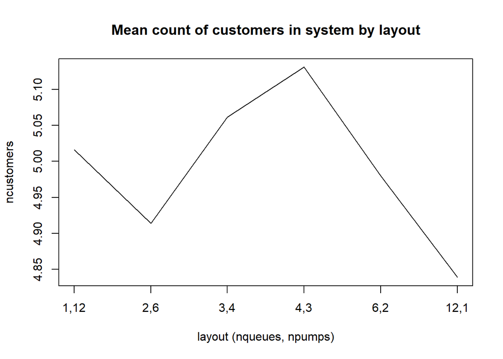

```r
plot(results_all[,"S_mean"], xaxt = "n", type="l",
     xlab="layout (nqueues, npumps)", ylab="ncustomers",
     main="Mean count of customers in system by layout")
axis(side = 1, at = seq(1, 6, by = 1),
     labels = c("1,12", "2,6", "3,4", "4,3", "6,2", "12,1"))
```

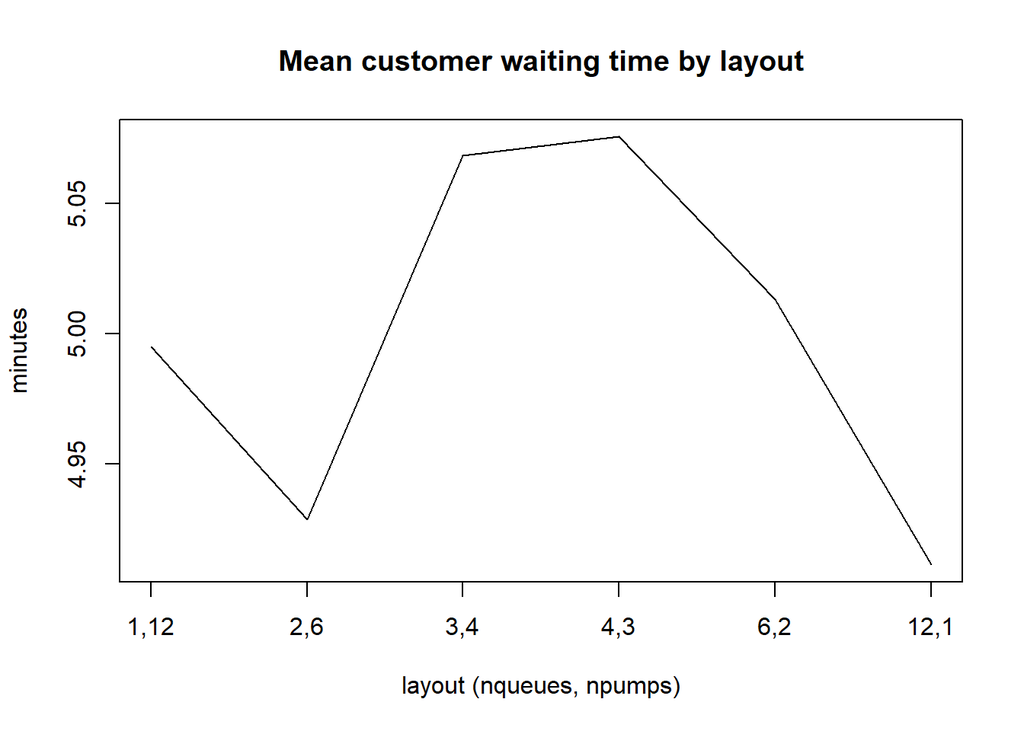

```r
plot(results_all[,"W_mean"], xaxt = "n", type="l",
     xlab="layout (nqueues, npumps)", ylab="minutes",
     main="Mean customer waiting time by layout")
axis(side = 1, at = seq(1, 6, by = 1),
     labels = c("1,12", "2,6", "3,4", "4,3", "6,2", "12,1"))
```

In general, for both cases with and without vehicle pump side preference, the effect size of changing the layout is relatively small, with the mean number of customers in the system staying at around 5 and the mean waiting time of a customer remaining at around 5 minutes.